# Tomey: Map Making

```r
require(tidyverse)
require(sf)
require(tigris)
require(geodata)
require(terra)
require(colorspace)
require(tidyterra)
require(ggnewscale)
require(cowplot)
```

# Short Explanatory Paragraph

## A couple sentence background about the study and study area you are mapping

Raccoon rabies is distributed along the eastern United States with Alabama serving as the westernmost front of the disease as well as management efforts. However, the fate of Oral Rabies Vaccine baits within Alabama is unknown. This study uses camera traps to evaluate the uptake of baits by target and non-target competitors.

This map highlights the northern area of the study that falls into the Eastern highland rim ecoregion. Within the region, we conducted sampling at Redstone Arsenal which is characterized by woody wetlands, relatively urban surroundings, and deciduous forest.

## Information on where you got your spatial elements and why you chose them.

### Vector Elements

1. Camera Locations Actual camera locations were recorded in the field using latitude and longitude. I loaded the CSV containing each camera location for the map. I used the location of cameras rather than the ‘site’ locations for data collection because it portrays more accurate locational data related to individual cameras related to a polygon overstretching the 12 cameras within each site.
2. Redstone Arsenal Boundary I created this polygon feature in ArcGIS pro by manually drawing the shape around the boundary portrayed by baselayer maps because I was unable to find a shapefile to directly download. I then uploaded the shapefile to the map. I chose to use the boundary for Redstone Arsenal rather than creating an extent box around the camera locations because I was held to sampling on the property.
3. Alabama Boundary The boundary of Alabama was downloaded from the USA states data available through RStudio. This was downloaded for the addition to my zoomed-out map and shows where RedStone Arsenal is located within the state as well as the relevant size.

### Raster Element

4. Elevation (30s) The elevation within Alabama along with my study area was downloaded directly from a package in RStudio. Camera/site locations in the study were split between upland and lowland areas. Elevation can be a simple but effective way to represent whether cameras represented upland or lowland habitat within the study area without diving into fine scale characteristics involved in defining those habitats.

# Raster and Vector Elements

## Camera Locations and Study Area Boundary

```r
camData = read.csv('https://raw.githubusercontent.com/rytomey/WILD7970_Spatial/main/W2_MapMaking/RSA_Cameras.csv')
```

[output not shown]

```r
camera = st_as_sf(camData, coords = c("Longitude", "Latitude"), crs='+proj=longlat +datum=WGS84 +no_defs +type=crs')
```

[output not shown]

```r
RSA_bound = st_read('/vsicurl/https://github.com/rytomey/WILD7970_Spatial/raw/main/W2_MapMaking/Redstone_Arsenal.shp')
```

[output not shown]

```r
#NAD_1983_CORS96_UTM_Zone_16N
RSA_bound = st_set_crs(RSA_bound, '+proj=utm +zone=16 +ellps=GRS80 +datum=NAD83 +units=m +no_defs')
```

[output not shown]

```r
st_crs(RSA_bound)
```

```
Coordinate Reference System:
  User input: +proj=utm +zone=16 +ellps=GRS80 +datum=NAD83 +units=m +no_defs
  wkt:
PROJCRS["unknown",
    BASEGEOGCRS["unknown",
        DATUM["North American Datum 1983",
            ELLIPSOID["GRS 1980",6378137,298.257222101,
                LENGTHUNIT["metre",1]],
            ID["EPSG",6269]],
        PRIMEM["Greenwich",0,
            ANGLEUNIT["degree",0.0174532925199433],
            ID["EPSG",8901]]],
    CONVERSION["UTM zone 16N",
        METHOD["Transverse Mercator",
            ID["EPSG",9807]],
        PARAMETER["Latitude of natural origin",0,
            ANGLEUNIT["degree",0.0174532925199433],
            ID["EPSG",8801]],
        PARAMETER["Longitude of natural origin",-87,
            ANGLEUNIT["degree",0.0174532925199433],
            ID["EPSG",8802]],
        PARAMETER["Scale factor at natural origin",0.9996,
            SCALEUNIT["unity",1],
            ID["EPSG",8805]],
        PARAMETER["False easting",500000,
            LENGTHUNIT["metre",1],
            ID["EPSG",8806]],
        PARAMETER["False northing",0,
            LENGTHUNIT["metre",1],
            ID["EPSG",8807]],
        ID["EPSG",16016]],
    CS[Cartesian,2],
        AXIS["(E)",east,
            ORDER[1],
            LENGTHUNIT["metre",1,
                ID["EPSG",9001]]],
        AXIS["(N)",north,
            ORDER[2],
            LENGTHUNIT["metre",1,
                ID["EPSG",9001]]]]
```

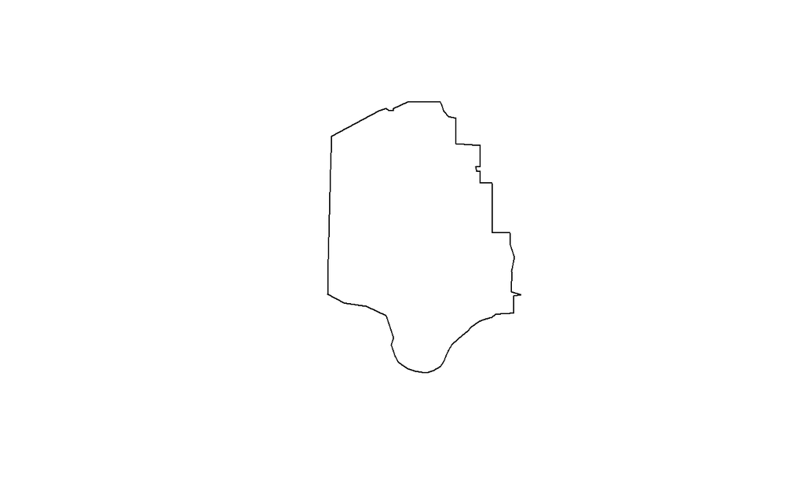

```r
plot(st_geometry(RSA_bound))
```

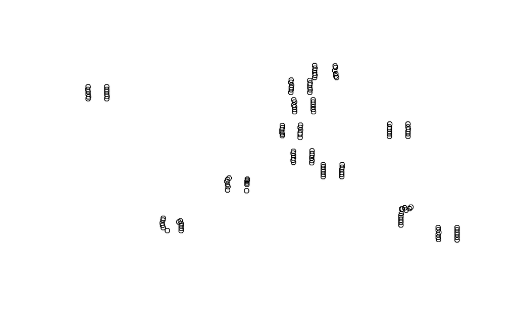

```r
plot(st_geometry(camera))
```

## Outline of Alabama

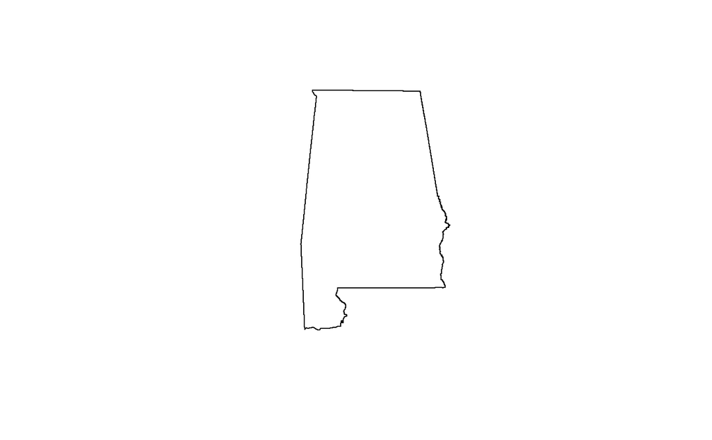

```r
alabama = states() %>%
  filter(NAME=='Alabama')
plot(st_geometry(alabama))
```

```r
st_crs(alabama)$proj4string
```

```
[1] "+proj=longlat +datum=NAD83 +no_defs"
```

```r
alabama = st_transform(alabama, st_crs(camera))
```

## Elevation: Alabama

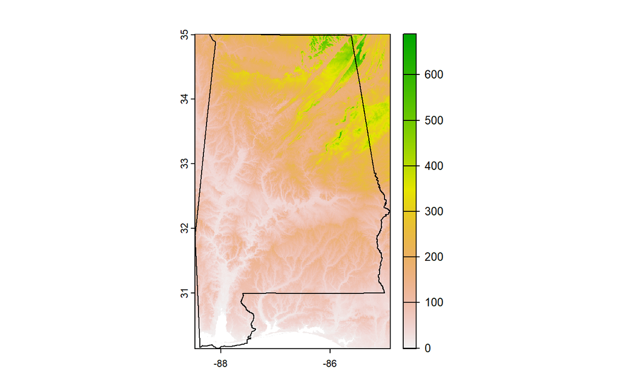

```r
usaElev = elevation_30s(country='USA', path=tempdir())

alabama = st_transform(alabama, st_crs(usaElev))
ALelev = crop(usaElev, alabama)

plot(ALelev)
plot(st_geometry(alabama), add=T)
```

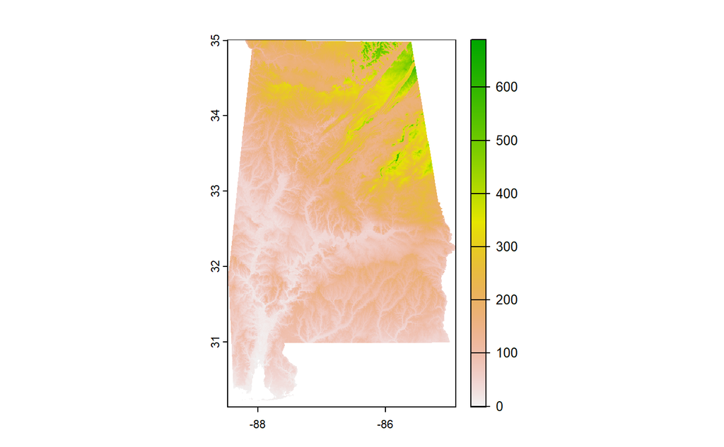

```r
ALelev = mask(ALelev, alabama)
plot(ALelev)
```

# Zoomed-Out Map

## Alabama showing Study Area + Cameras

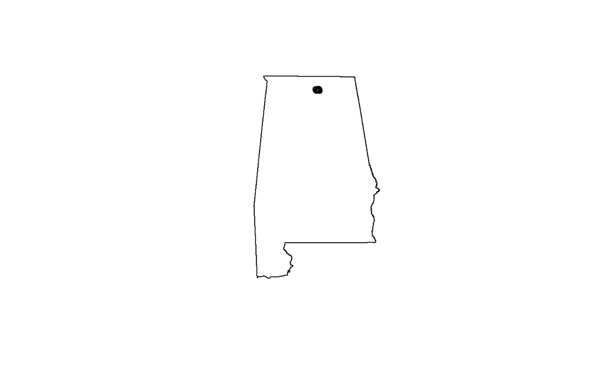

```r
plot(st_geometry(alabama))
plot(RSA_bound, col='blue', add=T)
plot(st_geometry(camera), add=T)
```

## Elevation within Redstone Arsenal

```r
RSA_bound = st_transform(RSA_bound, st_crs(alabama))
```

[output not shown]

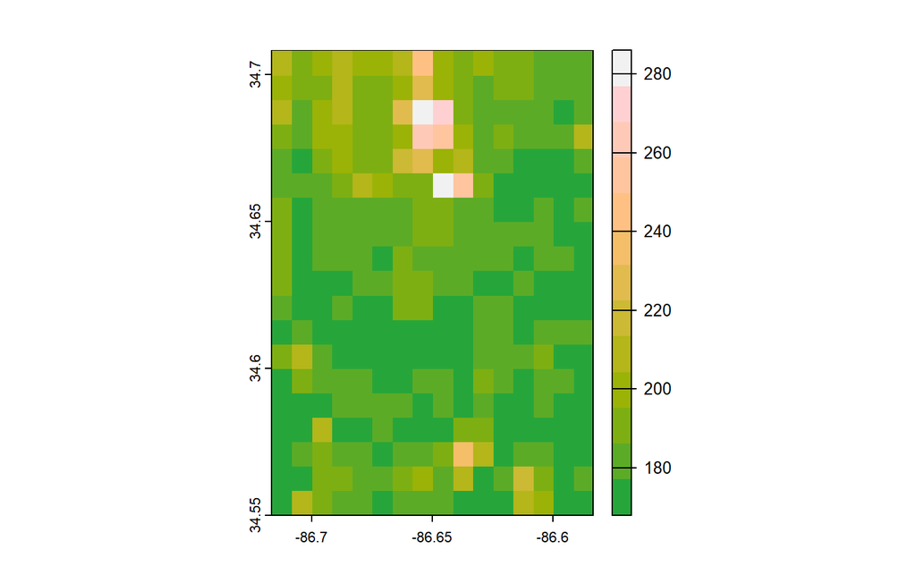

```r
RSAelev = crop(ALelev, RSA_bound)
plot(RSAelev, col=sequential_hcl(13, "Terrain"))
```

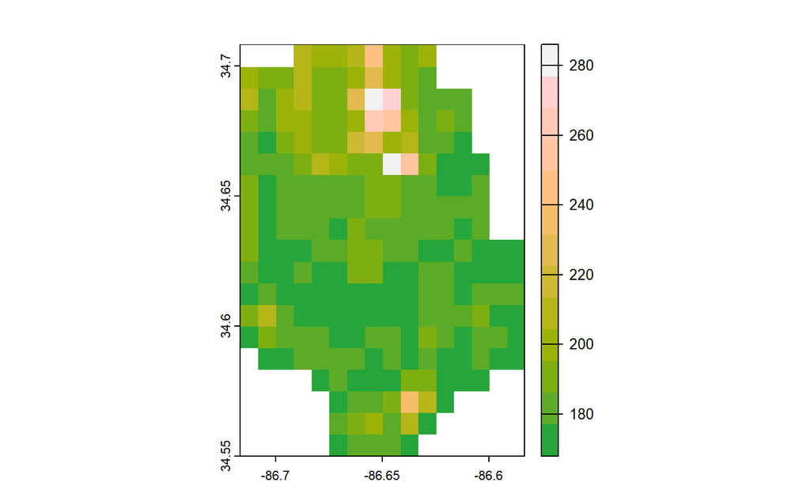

```r
RSAelev = mask(RSAelev, RSA_bound)
plot(RSAelev, col=sequential_hcl(13, "Terrain"))
```

# MAPS

## Zoomed-Out

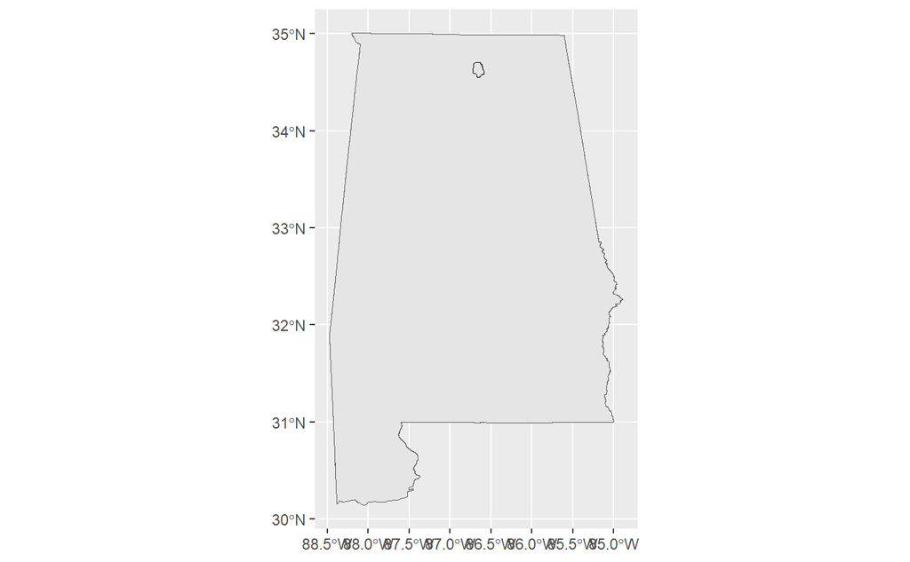

```r
zoomedOut = ggplot()+
  geom_sf(data = alabama)+
  geom_sf(data = RSA_bound, fill=NA, color='Black')
zoomedOut
```

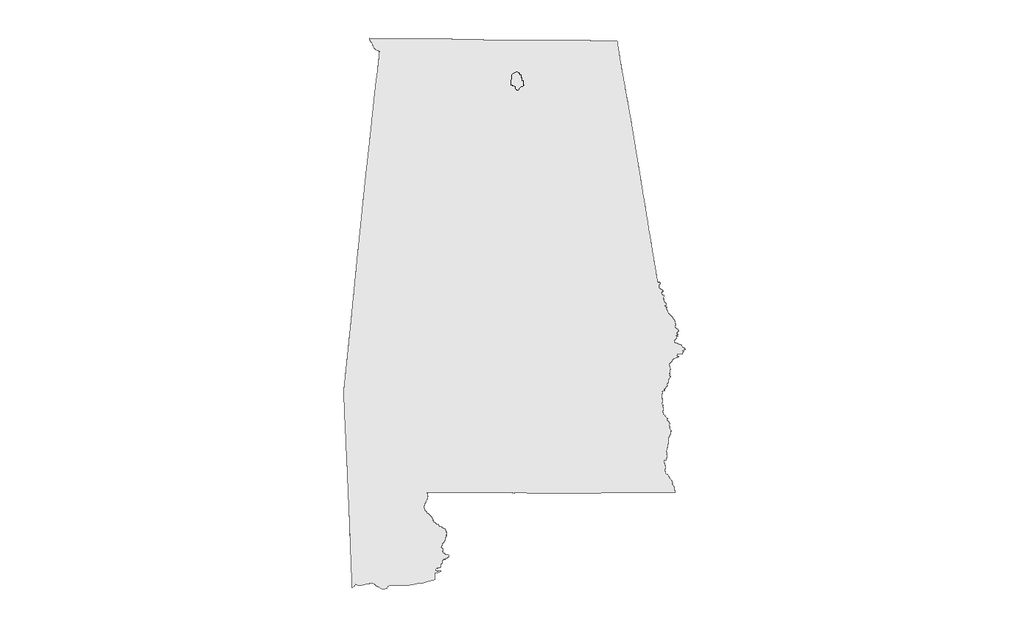

```r
zoomedOut = zoomedOut +
  theme_bw()+ #Gets rid of most of the colors
  theme(panel.grid=element_blank(), #Removes the gridlines
        axis.text=element_blank(), #Removes the axis text
        axis.ticks=element_blank(), #Removes the axis tick marks
        panel.border=element_blank()) #Removes the frame around the graph

zoomedOut
```

## Zoomed-In

Information on adding a scale bar and north arrow found at: https://stackoverflow.com/questions/61809382/how-can-i-put-a-scalebar-and-a-north-arrow-on-the-map-ggplot

```r
zoomedIn = ggplot()+
  geom_spatraster(data = RSAelev)+
  scale_fill_gradient(low='black', high='white', na.value='grey', labs(fill='Elevation'))

zoomedIn = zoomedIn +
  geom_sf(data = camera, aes(pch=Habitat), color='green')+
  scale_shape_manual(values=c(15, 17), name='Camera X Habitat')

zoomedIn = zoomedIn +
  theme_bw()+ #Gets rid of most of the colors
  theme(panel.grid=element_blank(), #Removes the gridlines
        axis.text=element_blank(), #Removes the axis text
        axis.ticks=element_blank(), #Removes the axis tick marks
        panel.border=element_blank()) #Removes the frame around the graph

install.packages(ggspatial)
```

[output not shown]

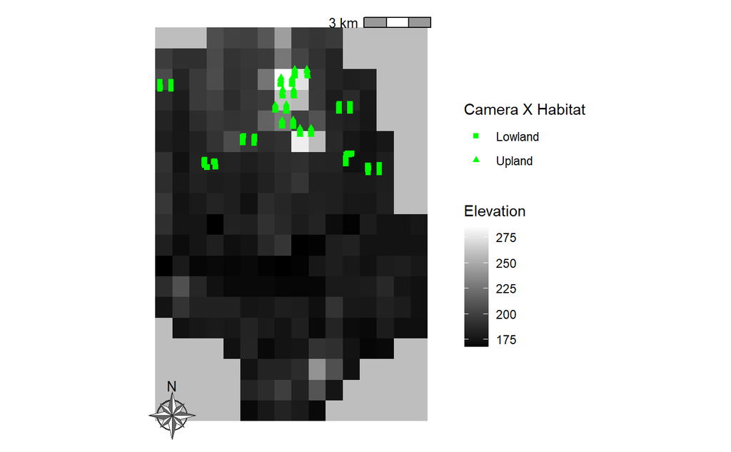

```r
library(ggspatial)

zoomedIn = zoomedIn +
  ggspatial::annotation_scale(
    location = "tr",
    bar_cols = c("grey60", "white"),
    text_cex = 0.8) +
  ggspatial::annotation_north_arrow(
    location = "bl", which_north = "true",
    pad_x = unit(0.01, "in"), pad_y = unit(0.01, "in"),
    style = ggspatial::north_arrow_nautical(
      fill = c("grey40", "white"),
      line_col = "grey20"))

zoomedIn
```

## Cowplotting

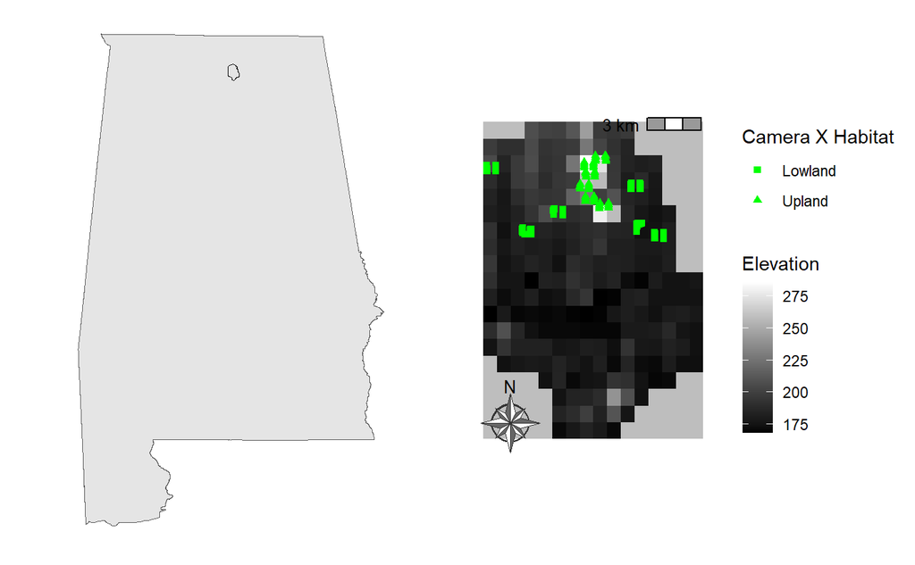

```r
plot_grid(zoomedOut, zoomedIn)
```

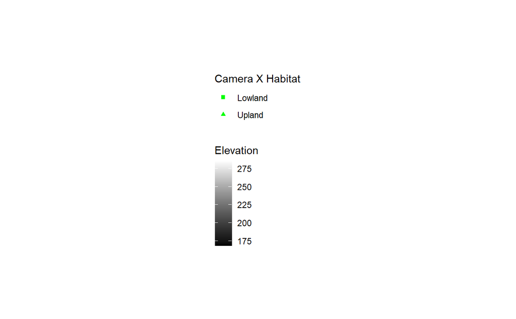

```r
legend = get_legend(zoomedIn)
ggdraw(legend)
```